# R Estudos

Introdução ao GIT

Leonardo Filgueira

## O que é o [GitHub](https://github.com/)?

- Hospedagem gratuita para *repositórios*.
- Permite criar e manter repositórios.
- Incentiva colaboração.

[figure not shown]

## Uso do github

### Código

[figure not shown]

## Uso do github

### Problemas

[figure not shown]

## O que é o GIT?

- Sistema de controle de versão.
- Software livre.
- Permite o *clone* de repositório remoto.
- Permite alteração de repositório remoto.

## [Download](https://git-scm.com/downloads)

[figure not shown]

## Configurando o GIT

### Definindo a identidade

Em **Git Bash**, digitamos:

```bash
git config --global user.name "nome_de_usuario"
git config --global user.email user@exemplo.com
```

## Configurando RStudio e GitHub

- Em tools > Global Options > Git/SVN, aperte em *Create RSA Key*
- Deve ser exibida a mensagem: *Your identification has been saved in…*.
- Clique em *View public key* e copie a key.
- Abra o github, clique na sua foto > Settings > SSH and GPG Keys > New SSH key.
- Coloque um título que lhe ajude a identificar de onde é a key, cole a key e confirme.

## Clonando [repositório](https://github.com/netododono/EER_git)

### Obtendo url

[figure not shown]

## Clonando projeto

### Utilizando o RStudio

- Abra um novo projeto.
- Selecione *Version Control*.
- Escolha *Git*.
- Cole a *url* do repositório.

## Fazendo e obtendo modificações

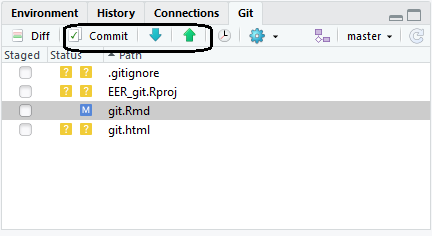

- *Pull*
- *Commit*
- *Push*

## Pull

- *Puxa* as modificações do repositório remoto (GitHub).
- Necessário para atualizar o repositório antes de enviar modificações.

## Commit

- Mensagem de modificação dos arquivos.

[figure not shown]

## Push

- Envia os commits ao repositório remoto (se for autorizado pelo mantenedor).
- Importante o repositório estar atualizado.

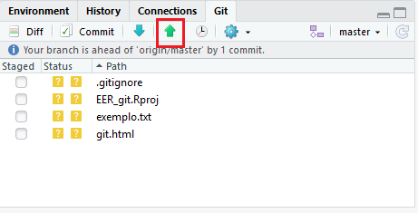

## Observações

- O arquivo local *.Rproj* nunca deve ser enviado para o GitHub. Caso ele seja acidentalmente enviado, deve ser removido pelo site.
- Mudei localização do repositório no github.

```bash
git remote set-url origin git@github.com:leo-filgueira/EER_git.git
```

## Branches

### Criando novo branch

- Criando branch local:

```bash
git checkout -b [nome_do_branch]
```

- Enviando para o repositório remoto:

```bash
git push -u origin [nome_do_branch]
```

## Branches

### Apontando branch local para branch remoto já existente

- Criando branch local:

```bash
git checkout -b [nome_do_branch]
```

## Referências e links úteis:

- [Adicionando SSH no github](https://help.github.com/articles/connecting-to-github-with-ssh/).
- [Git e github para usuários de R (livro)](http://happygitwithr.com/).
- [Configuração inicial do Git](https://git-scm.com/book/pt-br/v1/Primeiros-passos-Configura%C3%A7%C3%A3o-Inicial-do-Git).
- [Branches](https://stackoverflow.com/questions/520650/make-an-existing-git-branch-track-a-remote-branch)